# TITANIC

Elvi Khairunnisa

2022-04-20

# Exploratory Data Analysis

## 1. Pendahuluan

Pada LBB (*Learning by Building*) ini akan dilakukan *Exploratory Data Analysis* menggunakan *dataset* Titanic. *Dataset* ini berisi tentang biodata dari Penumpang Kapal Titanic yang akan ditentukan apakah biodata tersebut dapat digunakan untuk memprediksi penumpang tersebut selamat atau tidak.

## 2. Mengimport Data

Hal paling pertama yang harus dilakukan adalah pastikan lokasi folder *dataset* yang ingin diinput sama dengan *Rmd* ini. Kemudian, lanjut dengan *read dataset*. Ada dua file *dataset* yang digunakan yaitu *train.csv* dan *test.csv*.

```r
train<-read.csv("train.csv")
```

```r
test<-read.csv("test.csv")
```

Kedua *dataset* tersebut telah terbaca dan terinput dengan nama *train* dan *test*. Untuk mengetahui isi dari kedua *dataset* tersebut, lakukan ke tahap selanjutnya yaitu dengan cara menginspeksi data.

## 3. Menginspeksi Data

```r
head(train)
```

|  | PassengerId | Survived | Pclass | Name | Sex | Age | SibSp | Parch | Ticket | Fare | Cabin | Embarked |
| --- | --- | --- | --- | --- | --- | --- | --- | --- | --- | --- | --- | --- |
| 1 | 1 | 0 | 3 | Braund, Mr. Owen Harris | male | 22 | 1 | 0 | A/5 21171 | 7.2500 |  | S |
| 2 | 2 | 1 | 1 | Cumings, Mrs. John Bradley (Florence Briggs Thayer) | female | 38 | 1 | 0 | PC 17599 | 71.2833 | C85 | C |
| 3 | 3 | 1 | 3 | Heikkinen, Miss. Laina | female | 26 | 0 | 0 | STON/O2. 3101282 | 7.9250 |  | S |
| 4 | 4 | 1 | 1 | Futrelle, Mrs. Jacques Heath (Lily May Peel) | female | 35 | 1 | 0 | 113803 | 53.1000 | C123 | S |
| 5 | 5 | 0 | 3 | Allen, Mr. William Henry | male | 35 | 0 | 0 | 373450 | 8.0500 |  | S |
| 6 | 6 | 0 | 3 | Moran, Mr. James | male | NA | 0 | 0 | 330877 | 8.4583 |  | Q |

```r
head(test)
```

|  | PassengerId | Pclass | Name | Sex | Age | SibSp | Parch | Ticket | Fare | Cabin | Embarked |
| --- | --- | --- | --- | --- | --- | --- | --- | --- | --- | --- | --- |
| 1 | 892 | 3 | Kelly, Mr. James | male | 34.5 | 0 | 0 | 330911 | 7.8292 |  | Q |
| 2 | 893 | 3 | Wilkes, Mrs. James (Ellen Needs) | female | 47.0 | 1 | 0 | 363272 | 7.0000 |  | S |
| 3 | 894 | 2 | Myles, Mr. Thomas Francis | male | 62.0 | 0 | 0 | 240276 | 9.6875 |  | Q |
| 4 | 895 | 3 | Wirz, Mr. Albert | male | 27.0 | 0 | 0 | 315154 | 8.6625 |  | S |
| 5 | 896 | 3 | Hirvonen, Mrs. Alexander (Helga E Lindqvist) | female | 22.0 | 1 | 1 | 3101298 | 12.2875 |  | S |
| 6 | 897 | 3 | Svensson, Mr. Johan Cervin | male | 14.0 | 0 | 0 | 7538 | 9.2250 |  | S |

head () digunakan untuk mengetahui 6 baris data pertama.

```r
tail(train)
```

|  | PassengerId | Survived | Pclass | Name | Sex | Age | SibSp | Parch | Ticket | Fare | Cabin | Embarked |
| --- | --- | --- | --- | --- | --- | --- | --- | --- | --- | --- | --- | --- |
| 886 | 886 | 0 | 3 | Rice, Mrs. William (Margaret Norton) | female | 39 | 0 | 5 | 382652 | 29.125 |  | Q |
| 887 | 887 | 0 | 2 | Montvila, Rev. Juozas | male | 27 | 0 | 0 | 211536 | 13.000 |  | S |
| 888 | 888 | 1 | 1 | Graham, Miss. Margaret Edith | female | 19 | 0 | 0 | 112053 | 30.000 | B42 | S |
| 889 | 889 | 0 | 3 | Johnston, Miss. Catherine Helen "Carrie" | female | NA | 1 | 2 | W./C. 6607 | 23.450 |  | S |
| 890 | 890 | 1 | 1 | Behr, Mr. Karl Howell | male | 26 | 0 | 0 | 111369 | 30.000 | C148 | C |
| 891 | 891 | 0 | 3 | Dooley, Mr. Patrick | male | 32 | 0 | 0 | 370376 | 7.750 |  | Q |

```r
tail(test)
```

|  | PassengerId | Pclass | Name | Sex | Age | SibSp | Parch | Ticket | Fare | Cabin | Embarked |
| --- | --- | --- | --- | --- | --- | --- | --- | --- | --- | --- | --- |
| 413 | 1304 | 3 | Henriksson, Miss. Jenny Lovisa | female | 28.0 | 0 | 0 | 347086 | 7.7750 |  | S |
| 414 | 1305 | 3 | Spector, Mr. Woolf | male | NA | 0 | 0 | A.5. 3236 | 8.0500 |  | S |
| 415 | 1306 | 1 | Oliva y Ocana, Dona. Fermina | female | 39.0 | 0 | 0 | PC 17758 | 108.9000 | C105 | C |
| 416 | 1307 | 3 | Saether, Mr. Simon Sivertsen | male | 38.5 | 0 | 0 | SOTON/O.Q. 3101262 | 7.2500 |  | S |
| 417 | 1308 | 3 | Ware, Mr. Frederick | male | NA | 0 | 0 | 359309 | 8.0500 |  | S |
| 418 | 1309 | 3 | Peter, Master. Michael J | male | NA | 1 | 1 | 2668 | 22.3583 |  | C |

tail () digunakan untuk mengetahui 6 baris data terakhir.

```r
dim (train)
```

```
## [1] 891  12
```

```r
dim(test)
```

```
## [1] 418  11
```

dim () digunakan untuk mengetahui banyak baris dan kolom dari tabel *dataset* tersebut.

```r
colnames(train)
```

```
##  [1] "PassengerId" "Survived"    "Pclass"      "Name"        "Sex"
##  [6] "Age"         "SibSp"       "Parch"       "Ticket"      "Fare"
## [11] "Cabin"       "Embarked"
```

```r
colnames(test)
```

```
##  [1] "PassengerId" "Pclass"      "Name"        "Sex"         "Age"
##  [6] "SibSp"       "Parch"       "Ticket"      "Fare"        "Cabin"
## [11] "Embarked"
```

colnames() digunakan untuk mengetahui nama kolom pada tabel *dataset* tersebut.

Karena terdapat dua *dataset*, agar dapat digunakan dan diolah, maka perlu dilakukan penggabungan *dataset*. Sebelum dilakukan penggabungan, dilakukan proses pembuatan kolom baru pada *dataset test* (karena kolom *dataset* test lebih sedikit dari train) yaitu kolom Survived dengan nilai NA yang bertujuan agar jumlah kolom sama dan dapat digabungkan.

```r
test$Survived <- NA
titanic <- rbind(train, test)
head(titanic)
```

|  | PassengerId | Survived | Pclass | Name | Sex | Age | SibSp | Parch | Ticket | Fare | Cabin | Embarked |
| --- | --- | --- | --- | --- | --- | --- | --- | --- | --- | --- | --- | --- |
| 1 | 1 | 0 | 3 | Braund, Mr. Owen Harris | male | 22 | 1 | 0 | A/5 21171 | 7.2500 |  | S |
| 2 | 2 | 1 | 1 | Cumings, Mrs. John Bradley (Florence Briggs Thayer) | female | 38 | 1 | 0 | PC 17599 | 71.2833 | C85 | C |
| 3 | 3 | 1 | 3 | Heikkinen, Miss. Laina | female | 26 | 0 | 0 | STON/O2. 3101282 | 7.9250 |  | S |
| 4 | 4 | 1 | 1 | Futrelle, Mrs. Jacques Heath (Lily May Peel) | female | 35 | 1 | 0 | 113803 | 53.1000 | C123 | S |
| 5 | 5 | 0 | 3 | Allen, Mr. William Henry | male | 35 | 0 | 0 | 373450 | 8.0500 |  | S |
| 6 | 6 | 0 | 3 | Moran, Mr. James | male | NA | 0 | 0 | 330877 | 8.4583 |  | Q |

```r
tail(titanic)
```

|  | PassengerId | Survived | Pclass | Name | Sex | Age | SibSp | Parch | Ticket | Fare | Cabin | Embarked |
| --- | --- | --- | --- | --- | --- | --- | --- | --- | --- | --- | --- | --- |
| 1304 | 1304 | NA | 3 | Henriksson, Miss. Jenny Lovisa | female | 28.0 | 0 | 0 | 347086 | 7.7750 |  | S |
| 1305 | 1305 | NA | 3 | Spector, Mr. Woolf | male | NA | 0 | 0 | A.5. 3236 | 8.0500 |  | S |
| 1306 | 1306 | NA | 1 | Oliva y Ocana, Dona. Fermina | female | 39.0 | 0 | 0 | PC 17758 | 108.9000 | C105 | C |
| 1307 | 1307 | NA | 3 | Saether, Mr. Simon Sivertsen | male | 38.5 | 0 | 0 | SOTON/O.Q. 3101262 | 7.2500 |  | S |
| 1308 | 1308 | NA | 3 | Ware, Mr. Frederick | male | NA | 0 | 0 | 359309 | 8.0500 |  | S |
| 1309 | 1309 | NA | 3 | Peter, Master. Michael J | male | NA | 1 | 1 | 2668 | 22.3583 |  | C |

```r
dim(titanic)
```

```
## [1] 1309   12
```

```r
colnames(titanic)
```

```
##  [1] "PassengerId" "Survived"    "Pclass"      "Name"        "Sex"
##  [6] "Age"         "SibSp"       "Parch"       "Ticket"      "Fare"
## [11] "Cabin"       "Embarked"
```

Dari setiap kolom tersebut, akan dilakukan pengecekan tipe data yaitu dengan menggunakan str ()

```r
str(titanic)
```

```
## 'data.frame':    1309 obs. of  12 variables:
##  $ PassengerId: int  1 2 3 4 5 6 7 8 9 10 ...
##  $ Survived   : int  0 1 1 1 0 0 0 0 1 1 ...
##  $ Pclass     : int  3 1 3 1 3 3 1 3 3 2 ...
##  $ Name       : chr  "Braund, Mr. Owen Harris" "Cumings, Mrs. John Bradley (Florence Briggs Thayer)" "Heikkinen, Miss. Laina" "Futrelle, Mrs. Jacques Heath (Lily May Peel)" ...
##  $ Sex        : chr  "male" "female" "female" "female" ...
##  $ Age        : num  22 38 26 35 35 NA 54 2 27 14 ...
##  $ SibSp      : int  1 1 0 1 0 0 0 3 0 1 ...
##  $ Parch      : int  0 0 0 0 0 0 0 1 2 0 ...
##  $ Ticket     : chr  "A/5 21171" "PC 17599" "STON/O2. 3101282" "113803" ...
##  $ Fare       : num  7.25 71.28 7.92 53.1 8.05 ...
##  $ Cabin      : chr  "" "C85" "" "C123" ...
##  $ Embarked   : chr  "S" "C" "S" "S" ...
```

Atau juga dapat menggunakan sapply(#object, class), untuk mengecek tipe data setiap kolom

```r
sapply(titanic,class)
```

```
## PassengerId    Survived      Pclass        Name         Sex         Age
##   "integer"   "integer"   "integer" "character" "character"   "numeric"
##       SibSp       Parch      Ticket        Fare       Cabin    Embarked
##   "integer"   "integer" "character"   "numeric" "character" "character"
```

Agar memperoleh pengolahan data yang benar, ubah beberapa tipe data kolom menjadi factor

```r
titanic[, c("Pclass","Sex","SibSp","Parch","Embarked","Survived")] <- lapply(
  titanic[, c("Pclass","Sex","SibSp","Parch","Embarked","Survived")], as.factor)
```

Cek kembali tipe datanya

```r
sapply(titanic,class)
```

```
## PassengerId    Survived      Pclass        Name         Sex         Age
##   "integer"    "factor"    "factor" "character"    "factor"   "numeric"
##       SibSp       Parch      Ticket        Fare       Cabin    Embarked
##    "factor"    "factor" "character"   "numeric" "character"    "factor"
```

Kemudian cek *missing value* apakah ada atau tidak

```r
anyNA(titanic)
```

```
## [1] TRUE
```

Ternyata ada *missing value*. Untuk lebih memastikan tidak ada *missing value* pada setiap kolom, gunakan is.na pada kolom

```r
colSums(is.na(titanic))
```

```
## PassengerId    Survived      Pclass        Name         Sex         Age
##           0         418           0           0           0         263
##       SibSp       Parch      Ticket        Fare       Cabin    Embarked
##           0           0           0           1           0           0
```

Ternyata terdapat 418 NA pada kolom Survived, 263 NA pada kolom Age dan 1 NA pada kolom Fare. Agar datanya dapat digunakan, dilakukan proses imputasi dengan nilai NA menggunakan nilai median pada kolom Age dan Fare, sedangkan kolom Survived tidak perlu dilakukan.

```r
median(titanic$Age[!is.na(titanic$Age)])
```

```
## [1] 28
```

```r
median(titanic$Fare[!is.na(titanic$Fare)])
```

```
## [1] 14.4542
```

```r
titanic$Age[is.na(titanic$Age)] = 28
titanic$Fare[is.na(titanic$Fare)] = 14.454
```

```r
colSums(is.na(titanic))
```

```
## PassengerId    Survived      Pclass        Name         Sex         Age
##           0         418           0           0           0           0
##       SibSp       Parch      Ticket        Fare       Cabin    Embarked
##           0           0           0           0           0           0
```

Terlihat bahwa sudah tidak ada *missing value* pada kolom Age dan Fare, sehingga data siap diolah.

## 4. Mengolah Data

```r
summary(titanic)
```

```
##   PassengerId   Survived   Pclass      Name               Sex
##  Min.   :   1   0   :549   1:323   Length:1309        female:466
##  1st Qu.: 328   1   :342   2:277   Class :character   male  :843
##  Median : 655   NA's:418   3:709   Mode  :character
##  Mean   : 655
##  3rd Qu.: 982
##  Max.   :1309
##
##       Age        SibSp       Parch         Ticket               Fare
##  Min.   : 0.17   0:891   0      :1002   Length:1309        Min.   :  0.000
##  1st Qu.:22.00   1:319   1      : 170   Class :character   1st Qu.:  7.896
##  Median :28.00   2: 42   2      : 113   Mode  :character   Median : 14.454
##  Mean   :29.50   3: 20   3      :   8                      Mean   : 33.281
##  3rd Qu.:35.00   4: 22   4      :   6                      3rd Qu.: 31.275
##  Max.   :80.00   5:  6   5      :   6                      Max.   :512.329
##                  8:  9   (Other):   4
##     Cabin           Embarked
##  Length:1309         :  2
##  Class :character   C:270
##  Mode  :character   Q:123
##                     S:914
##
##
##
```

Untuk lebih jelas, dilakukan pembuatan plot pada beberapa variabel.

## 5. Pembuatan Plot

*Barplot Penumpang Selamat dan Tidak Selamat*

Diperoleh dari summary (titanic) penumpang selamat = 342 orang, tidak selamat = 549 orang.

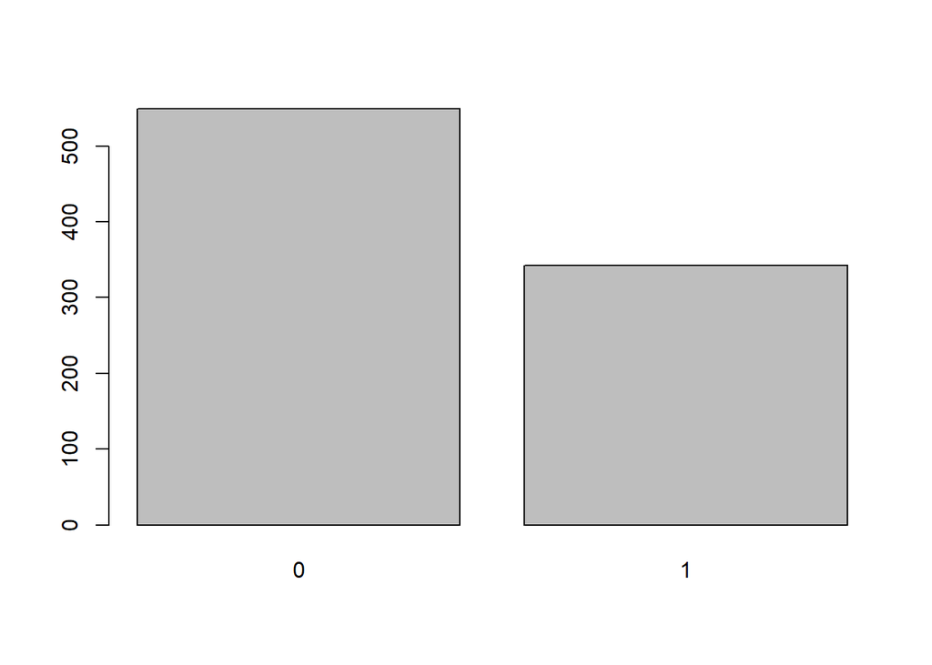

```r
barplot(table(titanic$Survived))
```

*Plot Berupa Proporsi Penumpang Selamat dan Tidak Selamat Menurut Jenis Kelamin*

Proporsinya:

```r
prop.table(table(titanic$Sex, titanic$Survived))*100
```

```
##
##                  0         1
##   female  9.090909 26.150393
##   male   52.525253 12.233446
```

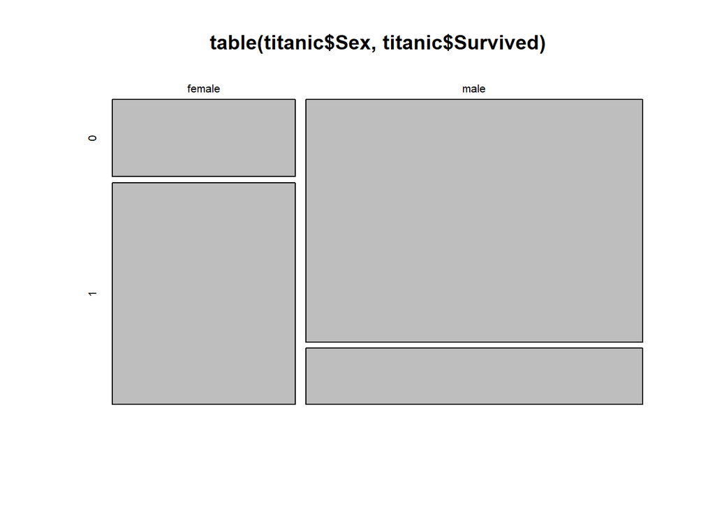

```r
plot(table(titanic$Sex, titanic$Survived))
```

*Plot Penumpang Selamat dan Tidak Selamat Menurut Tipe Kelas (Pclass)*

Agar plot lebih jelas dilakukan penggantian nama pada isi kolom Pclass

```r
titanic$Pclass <- sapply(as.character(titanic$Pclass), switch,
                         "1" = "1st Class",
                         "2" = "2nd Class",
                         "3" = "3rd Class")
```

```r
table(titanic$Survived, titanic$Pclass)
```

```
##
##     1st Class 2nd Class 3rd Class
##   0        80        97       372
##   1       136        87       119
```

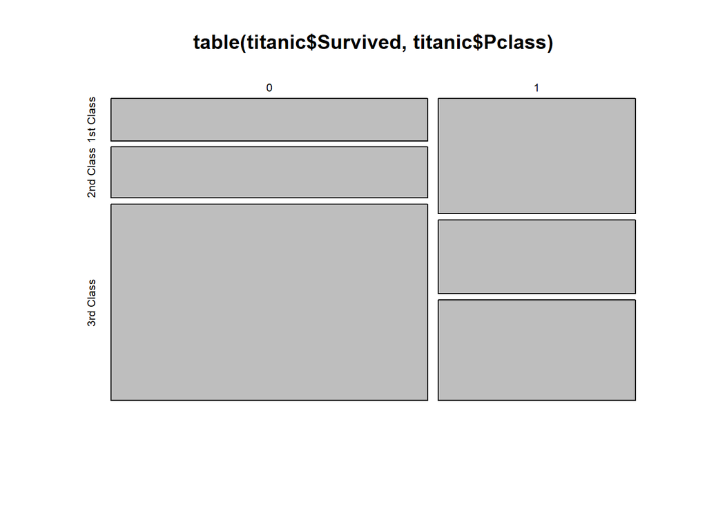

```r
plot(table(titanic$Survived, titanic$Pclass))
```

Dapat dilihat bahwa jumlah penumpang yang memesan tiket 1st Class lebih banyak yang selamat daripada yang tidak selamat, penumpang yang memesan tiket 2nd Class seimbang jumlah yang selamat dan tidak selamatnya, dan penumpang yang memesan tiket 3rd Class lebih banyak yang tidak selamat daripada yang selamat.

## 6. Kesimpulan

Ternyata banyak faktor yang mempengaruhi tingkat keselamatan dari penumpang kapal Titanic. Mulai dari jenis kelamin (sex), Pclass dan masih banyak lagi. Dataset ini masih dapat dieksplor lebih dalam lagi sehingga dapat mendapatkan kesimpulan yang lebih baik dan akurat.